# Housing Affordability Across Ontario Municipalities

Kieran Shah

2026-09-14

## Introduction and Purpose

Affordability is major concern across Ontario.

- A recent poll conducted by Angus Reid identified the cost of living and housing affordability as a the most important issue.

This presentation will seek to **identify which factors are most associated with affordability** using Statistics Canada data and a regression model.

Statistics Canada provided the two main data sources for this presentation at the **Census Subdivision level (CSD)**:

1. `Table 98-10-0247-01` provided affordability variables.
2. `Table 98-401-X2021021` is the summary of the predictor variables.

## EDA: Affordability Distribution

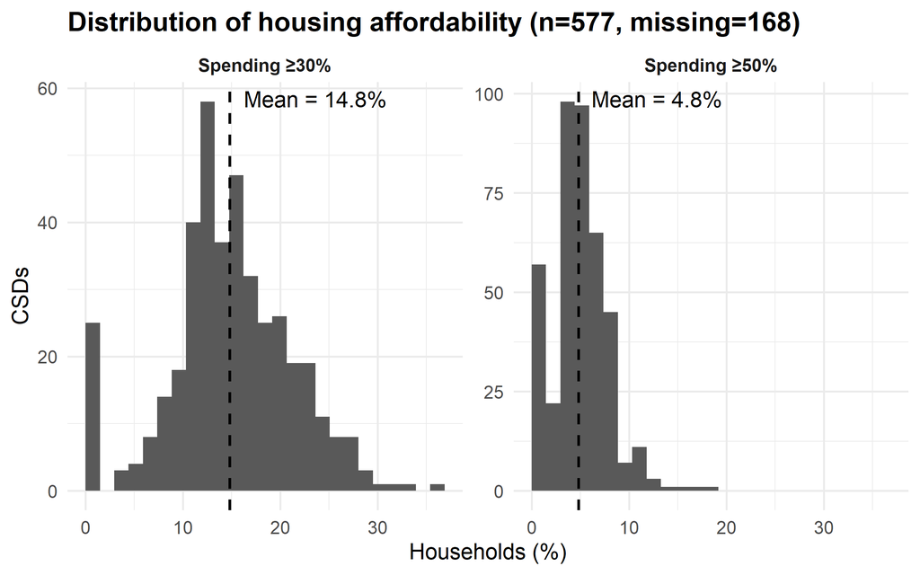

## Affordability Map

[interactive chart not shown]

## EDA Predictors

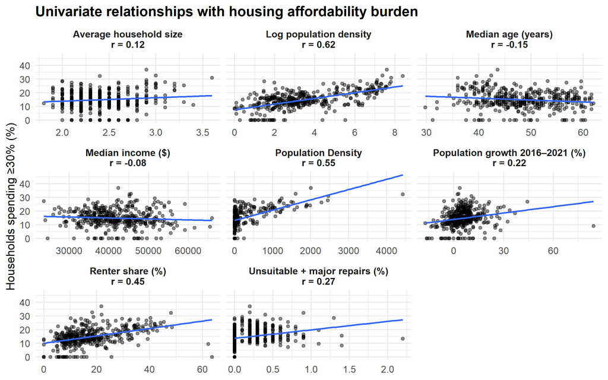

## Modelling Approach

Summary of candidate predictors

| Variable | mean | median | q1 | q3 |
| --- | --- | --- | --- | --- |
| Percent Renting | 17.7 | 15.1 | 10.0 | 22.8 |
| Median Age | 48.3 | 48.0 | 43.2 | 54.1 |
| Median Total Income | 4.2 | 4.1 | 3.7 | 4.6 |
| Hundreds of people per km2 | 2.0 | 0.2 | 0.1 | 0.9 |
| Average Household Size | 2.4 | 2.4 | 2.2 | 2.6 |
| Not suitable and major repairs needed | 0.3 | 0.0 | 0.0 | 0.3 |
| 2016 to 2021 population growth | 5.8 | 4.8 | 0.3 | 9.3 |

We run two types of regression to model the two affordability metrics.

1. OLS: models the conditional mean of affordability percentage as a linear function of the predictors.
2. Fractional Logit: models affordability as an expected affordability proportion, ensuring all fitted values are between 0 and 1.

## Best way to model

- We compared OLS and fractional logit regression and found very little difference in predictive performance.

10-fold cross-validation RMSE (percentage points)

| Outcome | OLS | Fractional logit |
| --- | --- | --- |
| 30%+ affordability | 4.59 | 4.64 |
| 50%+ severe affordability | 2.47 | 2.51 |

In addition, we conducted sensitivity analyses with the log of population density.

## Model Results

Fractional logistic regression results

| Predictor | 30%+ Estimate | 30%+ AME | 50%+ Estimate | 50%+ AME |
| --- | --- | --- | --- | --- |
| (Intercept) | 0.915*** | -74.607 | 1.238*** | -36.437 |
| renter_pct | 0.006*** | 0.301 | 0.007** | 0.093 |
| median_age | 0.008*** | 0.432 | 0.010*** | 0.187 |
| income_10k | 0.046* | -1.175 | 0.059 | -0.235 |
| density_100 | 0.008** | 0.313 | 0.009** | 0.129 |
| avg_hh_size | 0.190*** | 11.881 | 0.280*** | 4.882 |
| unsuitable_repairs_pct | 0.084** | 3.188 | 0.080*** | 1.551 |
| pop_growth_pct | 0.004*** | 0.185 | 0.007* | 0.073 |

- As we can see the estimates between the two outcomes are not substantially different.
  - A one-person increase in average household size is associated with an approximately **12 percentage-point increase** in the share of households experiencing affordability challenges.
  - A one-point increase in the percent of unsuitable/disrepair dwellings is associated with a **3 percentage-point increase** in the share of households experiencing affordability challenges.

## Other data sources:

- The CMHC and Ontario Government provide two additional data sources.

Ten CSDs with the highest 30%+ affordability burden

| Municipality | Household Size (2.6) | % Renter (22.8%) | 30%+ (%) | Housing target status | 2020 starts per 1,000 |
| --- | --- | --- | --- | --- | --- |
| Richmond Hill | 2.9 | 21.8 | 36.9 | Not met | 0.0 |
| Markham | 3.0 | 18.3 | 32.6 | Not met | 0.0 |
| Toronto | 2.4 | 48.1 | 32.2 | Exceeded | 0.0 |
| Brampton | 3.6 | 21.9 | 30.9 | On track | 0.7 |
| Aurora | 2.9 | 18.8 | 29.3 | Not met | 0.0 |
| Parry Sound | 2.0 | 40.4 | 28.5 |  | 0.0 |
| Tehkummah | 2.0 | 10.2 | 28.3 |  | 0.0 |
| Mississauga | 2.9 | 29.6 | 27.9 | Not met | 0.0 |
| Vaughan | 3.1 | 14.1 | 27.8 | Not met | 0.0 |
| Oshawa | 2.6 | 35.8 | 27.5 | Not met | 0.1 |

## Limitations and Policy Implications

There are many limitations to this study:

1. There is no time element.
   1. We’re unable to capture the trend in affordability. Using cross sectional data prevents us from answering the very simple question of ‘is affordability worse?’.
   2. CMHC data only went as far back as 2020. Housing starts captures January 2020 starts and does not allow us to see a five or ten-year trend.
2. The 2021 Census was affected by Covid-19